# UFRPE/DEINFO/PPGBEA Laboratório – Regressão Linear Múltipla

### – Correlação entre as variáveis

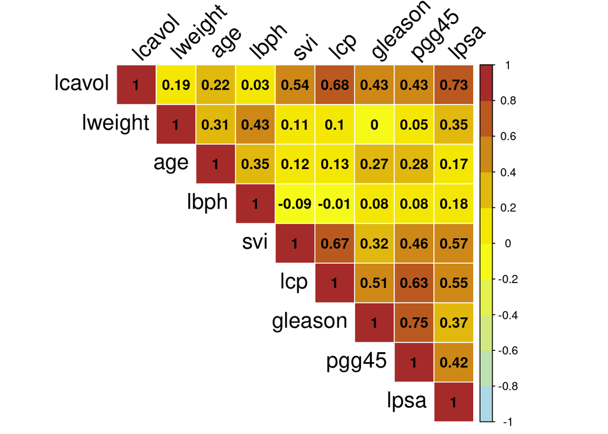

```r
M <- cor(dados, method = "pearson")
library(corrplot)
library(RColorBrewer)
corrplot(M, type = "upper", method = "color", order = "original", outline = "white",
        tl.col="black", tl.srt=45, addCoef.col = "black", tl.cex = 1.5, number.cex = 1.0,
        col = colorRampPalette(c("lightblue", "yellow", "brown"))(10))
```

$\textbf{Análise:}$ Por meio do gráfico de correlação entre as variáveis explicativas é possível verificar que existem algumas variáveis relacionadas e que podem causar multicolineariedade. Veja por exemplo entre as variáveis $\textbf{lcavol}$ e $\textbf{svi}$. Essa análise será feita mais adiante por meio do VIF (Fator de Inflação de Variância)

### – Regressão Linear Múltipla

```r
# Auxiliares
nobs <- dim(dados)[1]
npar <- dim(dados)[2]

# matriz X
library("dplyr")
Covariaveis <- as.matrix(select(dados, -lpsa))
X <- cbind(1, Covariaveis)
Y <- dados[,9]

# vetor b
b <- solve(t(X)%*%X) %*% t(X)%*%Y

# Resíduos
echapeu <- Y - X%*%b

# Estimativa de sigma^2
sigma2chapeu <- crossprod(echapeu)/(nobs-npar)

# Erros-padrão
erroP <- sqrt(as.double(sigma2chapeu)*diag(solve(t(X)%*%X)))

# t-valor (Estatística de teste)
tvalor <- b/erroP

# p-valor
pvalor <- 2*(1-pt(abs(tvalor), df = nobs-npar))

# Medidas de Bondade de Ajuste
Yest  <- X%*%b
SQT   <- sum((Y-mean(Y))^2)
SQRes <- sum((Y - Yest)^2)
aux   <- (nobs - 1)/(nobs - npar)

# Coeficiente de determinação
R2   <- 1 - SQRes/SQT
R2a  <- 1 - aux*(1-R2) ## R2 ajustado
R2nc <- 1 - crossprod(erroP)/crossprod(Y) ## R2 não ajustado

# Critérios de informações
AIC <- nobs*log(SQRes/nobs) + 2*npar
BIC <- nobs*log(SQRes/nobs) + npar*log(nobs)/nobs

# Impressão dos dados
imp <- cbind(b, erroP, tvalor, pvalor)
colnames(imp) <- c("Estimativas", "DesvioP", "t-valor", "p-valor")
rownames(imp) <- c("Intercepto", "lcavol", "lweight", "age", "lbph", "svi", "lcp", "gleason", "pgg45")

Cba <- rbind(R2, R2a, R2nc, AIC, BIC)
colnames(Cba) <- c("Critérios de seleção")
rownames(Cba) <- c("R2", "R2a", "R2nc", "AIC", "BIC")

kable(round(imp, 4), align = "c")
```

|  | Estimativas | DesvioP | t-valor | p-valor |
| --- | --- | --- | --- | --- |
| Intercepto | 0.6693 | 1.2964 | 0.5163 | 0.6069 |
| lcavol | 0.5870 | 0.0879 | 6.6767 | 0.0000 |
| lweight | 0.4545 | 0.1700 | 2.6731 | 0.0090 |
| age | -0.0196 | 0.0112 | -1.7576 | 0.0823 |
| lbph | 0.1071 | 0.0584 | 1.8316 | 0.0704 |
| svi | 0.7662 | 0.2443 | 3.1360 | 0.0023 |
| lcp | -0.1055 | 0.0910 | -1.1589 | 0.2496 |
| gleason | 0.0451 | 0.1575 | 0.2867 | 0.7750 |
| pgg45 | 0.0045 | 0.0044 | 1.0235 | 0.3089 |

```r
kable(round(Cba, 4), align = "c")
```

|  | Critérios de seleção |
| --- | --- |
| R2 | 0.6548 |
| R2a | 0.6234 |
| R2nc | 0.9975 |
| AIC | -58.3218 |
| BIC | -75.8974 |

$\textbf{Análise:}$ O resultado do teste de hipóteses acima mostra a estimativa de cada coeficiente associada ao respectivo teste de hipótese. Como em outros testes de hipóteses, rejeitamos $\mathcal{H}_0$ se o valor de $p$ associado ao coeficiente for igual o menor que o nível de significância adotado. Neste exemplo, o valor de $p$ associado aos $\beta$’s foi maior que 0,05 (5%) com exceção das varáveis volume do câncer, logaritmo do peso da próstata e invasão da vesícula seminal. Diante disso, não rejeitamos a hipótese nula, ou seja, os $\beta$’s são iguais a zero com exceção dos $\beta$’s associados as variveis $\textbf{lcavol}$, $\textbf{lweight}$ e $\textbf{svi}$. Note que os coeficientes de determinação estão dando valores razoavelmente bons. Vamos verificar se há multicolinearidade entre as variáveis.

### No $\texttt{R}$ os modelos lineares são resolvidos com a função $\texttt{lm}$.

### – Estimar os parâmetros do modelo – M1

```r
M1 <- lm(lpsa ~ lcavol + lweight + age + lbph + svi + lcp + gleason + pgg45, data = dados)
M1a <- summary(M1)
summary(M1)
```

```
##
## Call:
## lm(formula = lpsa ~ lcavol + lweight + age + lbph + svi + lcp +
##     gleason + pgg45, data = dados)
##
## Residuals:
##     Min      1Q  Median      3Q     Max
## -1.7331 -0.3713 -0.0170  0.4141  1.6381
##
## Coefficients:
##              Estimate Std. Error t value Pr(>|t|)
## (Intercept)  0.669337   1.296387   0.516  0.60693
## lcavol       0.587022   0.087920   6.677 2.11e-09 ***
## lweight      0.454467   0.170012   2.673  0.00896 **
## age         -0.019637   0.011173  -1.758  0.08229 .
## lbph         0.107054   0.058449   1.832  0.07040 .
## svi          0.766157   0.244309   3.136  0.00233 **
## lcp         -0.105474   0.091013  -1.159  0.24964
## gleason      0.045142   0.157465   0.287  0.77503
## pgg45        0.004525   0.004421   1.024  0.30886
## ---
## Signif. codes:  0 '***' 0.001 '**' 0.01 '*' 0.05 '.' 0.1 ' ' 1
##
## Residual standard error: 0.7084 on 88 degrees of freedom
## Multiple R-squared:  0.6548, Adjusted R-squared:  0.6234
## F-statistic: 20.86 on 8 and 88 DF,  p-value: < 2.2e-16
```

### – Multicolinearidade

```r
library("regclass", quietly = TRUE)
kable(VIF(M1), align = 'c', col.names = "VIF")
```

|  | VIF |
| --- | --- |
| lcavol | 2.054115 |
| lweight | 1.363704 |
| age | 1.323599 |
| lbph | 1.375534 |
| svi | 1.956881 |
| lcp | 3.097954 |
| gleason | 2.473411 |
| pgg45 | 2.974361 |

$\textbf{Análise:}$ Observamos que o VIF de todas as variáveis é menor que 5, ou seja, não há grandes evidências de ter multicolinearidade.

### – Estimar os parâmetros do modelo – M2

```r
M2 <- lm(lpsa ~ lcavol + lweight + age + lbph + svi + lcp, data = dados)
M2a <- summary(M2)
summary(M2)
```

```
##
## Call:
## lm(formula = lpsa ~ lcavol + lweight + age + lbph + svi + lcp,
##     data = dados)
##
## Residuals:
##      Min       1Q   Median       3Q      Max
## -1.82853 -0.40741  0.01695  0.47159  1.59040
##
## Coefficients:
##             Estimate Std. Error t value Pr(>|t|)
## (Intercept)  0.93487    0.83577   1.119  0.26630
## lcavol       0.58765    0.08663   6.783  1.2e-09 ***
## lweight      0.41808    0.16792   2.490  0.01462 *
## age         -0.01511    0.01081  -1.398  0.16546
## lbph         0.11381    0.05842   1.948  0.05452 .
## svi          0.78256    0.24261   3.226  0.00175 **
## lcp         -0.04118    0.08135  -0.506  0.61392
## ---
## Signif. codes:  0 '***' 0.001 '**' 0.01 '*' 0.05 '.' 0.1 ' ' 1
##
## Residual standard error: 0.7102 on 90 degrees of freedom
## Multiple R-squared:  0.6451, Adjusted R-squared:  0.6215
## F-statistic: 27.27 on 6 and 90 DF,  p-value: < 2.2e-16
```

$\textbf{Análise:}$ O resultado do teste de hipóteses acima mostra as estimativas de cada coeficiente associada ao respectivo teste de hipótese. Como em outros testes de hipóteses, rejeitamos $\mathcal{H}_0$ se o valor de $p$ associado ao coeficiente for igual o menor que o nível de significância adotado. Neste modelo, sem as variáveis $\textbf{gleason}$ e $\textbf{pgg45}$, os valores de $p$ associados a $\beta_2$, $\beta_3$ e $\beta_6$ foram menores que 0,05 (5%) o que é uma forte evidência de que o volume do câncer, o logarítmo do peso da próstata e a invasão da vesícula seminal, de fato, são significantes.

### – Multicolinearidade

```r
kable(VIF(M2), align = 'c', col.names = "VIF")
```

|  | VIF |
| --- | --- |
| lcavol | 1.984151 |
| lweight | 1.323687 |
| age | 1.232282 |
| lbph | 1.367276 |
| svi | 1.920062 |
| lcp | 2.462604 |

$\textbf{Análise:}$ Observamos que o VIF de todas as variáveis é menor que 5, ou seja, não há grandes evidências de ter multicolinearidade.

### – Estimar os parâmetros do modelo – M3

```r
M3 <- lm(lpsa ~ lcavol + lweight + lbph + svi, data = dados)
M3a <- summary(M3)
summary(M3)
```

```
##
## Call:
## lm(formula = lpsa ~ lcavol + lweight + lbph + svi, data = dados)
##
## Residuals:
##      Min       1Q   Median       3Q      Max
## -1.82653 -0.42270  0.04362  0.47041  1.48530
##
## Coefficients:
##             Estimate Std. Error t value Pr(>|t|)
## (Intercept)  0.14554    0.59747   0.244  0.80809
## lcavol       0.54960    0.07406   7.422 5.64e-11 ***
## lweight      0.39088    0.16600   2.355  0.02067 *
## lbph         0.09009    0.05617   1.604  0.11213
## svi          0.71174    0.20996   3.390  0.00103 **
## ---
## Signif. codes:  0 '***' 0.001 '**' 0.01 '*' 0.05 '.' 0.1 ' ' 1
##
## Residual standard error: 0.7108 on 92 degrees of freedom
## Multiple R-squared:  0.6366, Adjusted R-squared:  0.6208
## F-statistic: 40.29 on 4 and 92 DF,  p-value: < 2.2e-16
```

$\textbf{Análise:}$ Nesse terceiro modelo retiramos as variáveis $\textbf{age}$, $\textbf{lcp}$, $\textbf{gleason}$ e $\textbf{pgg45}$. Assim, observamos que às variáveis $\textbf{lcavol}$, $\textbf{lweight}$ e $\textbf{svi}$ são significantes.

### – Multicolinearidade

```r
kable(VIF(M3), align = 'c', col.names = "VIF")
```

|  | VIF |
| --- | --- |
| lcavol | 1.447473 |
| lweight | 1.291345 |
| lbph | 1.261576 |
| svi | 1.435481 |

$\textbf{Análise:}$ Observamos que o VIF de todas as variáveis é menor que 5, ou seja, não há grandes evidências de ter multicolinearidade.

### – Estimar os parâmetros do modelo – M4

```r
M4 <- lm(lpsa ~ lcavol + lweight + svi, data = dados)
M4a <- summary(M4)
summary(M4)
```

```
##
## Call:
## lm(formula = lpsa ~ lcavol + lweight + svi, data = dados)
##
## Residuals:
##      Min       1Q   Median       3Q      Max
## -1.72964 -0.45764  0.02812  0.46403  1.57013
##
## Coefficients:
##             Estimate Std. Error t value Pr(>|t|)
## (Intercept) -0.26809    0.54350  -0.493  0.62298
## lcavol       0.55164    0.07467   7.388  6.3e-11 ***
## lweight      0.50854    0.15017   3.386  0.00104 **
## svi          0.66616    0.20978   3.176  0.00203 **
## ---
## Signif. codes:  0 '***' 0.001 '**' 0.01 '*' 0.05 '.' 0.1 ' ' 1
##
## Residual standard error: 0.7168 on 93 degrees of freedom
## Multiple R-squared:  0.6264, Adjusted R-squared:  0.6144
## F-statistic: 51.99 on 3 and 93 DF,  p-value: < 2.2e-16
```

$\textbf{Análise:}$ Nessa quarta modelagem deixamos apenas as variáveis $\textbf{lcavol}$, $\textbf{lweight}$ e $\textbf{svi}$ pelo fato de serem significantes, a 95% de confiança. A seguir ilustramos o VIF dessas variáveis, na qual foram abaixo de 5, ou seja, há grandes evidências de não ter multicolinearidade.

### – Multicolinearidade

```r
kable(VIF(M4), align = 'c', col.names = "VIF")
```

|  | VIF |
| --- | --- |
| lcavol | 1.447048 |
| lweight | 1.039188 |
| svi | 1.409189 |

### – Comparação dos modelos

```r
## R2 não centrado
R2n1 <- 1 - crossprod(M1$resid)/crossprod(Y)
R2n2 <- 1 - crossprod(M2$resid)/crossprod(Y)
R2n3 <- 1 - crossprod(M3$resid)/crossprod(Y)
R2n4 <- 1 - crossprod(M4$resid)/crossprod(Y)

Mod1 <- c(AIC(M1), BIC(M1), M1a$r.squared, M1a$adj.r.squared, R2n1)
Mod2 <- c(AIC(M2), BIC(M2), M2a$r.squared, M2a$adj.r.squared, R2n2)
Mod3 <- c(AIC(M3), BIC(M3), M3a$r.squared, M3a$adj.r.squared, R2n3)
Mod4 <- c(AIC(M4), BIC(M4), M4a$r.squared, M4a$adj.r.squared, R2n4)

aux <- rbind(Mod1, Mod2, Mod3, Mod4)
colnames(aux) <- c("AIC", "BIC", "R2", "R2 Ajustado", "R2 Não centrado")
kable(aux, align = "c", digits = 4)
```

|  | AIC | BIC | R2 | R2 Ajustado | R2 Não centrado |
| --- | --- | --- | --- | --- | --- |
| Mod1 | 218.9522 | 244.6993 | 0.6548 | 0.6234 | 0.9390 |
| Mod2 | 217.6239 | 238.2215 | 0.6451 | 0.6215 | 0.9373 |
| Mod3 | 215.9223 | 231.3705 | 0.6366 | 0.6208 | 0.9358 |
| Mod4 | 216.5979 | 229.4714 | 0.6264 | 0.6144 | 0.9340 |

### – Teste Reset

#### – Para saber se precisa fazer transformação nos dados, ou seja, para verificar se o modelo está correto ou não na especificação usamos o teste $\texttt{Reset}$. As hipoteses são:

$$\begin{align*}
\mathcal{H}_0 &: \text{o modelo corretamente especificado}
\quad \text{versus} \quad
\mathcal{H}_1 : \text{o modelo incorretamente especificado}
\end{align*}$$

```r
try(require(lmtest, quietly = TRUE), silent=TRUE)
pvalor <- cbind(resettest(M1, type = "regressor")[4], resettest(M2, type = "regressor")[4],
resettest(M3, type = "regressor")[4], resettest(M4, type = "regressor")[4])

colnames(pvalor) <- c("Modelo 1", "Modelo 2", "Modelo 3", "Modelo 4")
rownames(pvalor) <- "p-valor"

kable(pvalor, align = "c")
```

|  | Modelo 1 | Modelo 2 | Modelo 3 | Modelo 4 |
| --- | --- | --- | --- | --- |
| p-valor | 0.500089396471649 | 0.34611831641669 | 0.38823703469354 | 0.405603006287091 |

### – Teste da razão de verossimilhança

```r
Ma1 <- lm(lpsa ~ svi, data = dados)
Ma2 <- lm(lpsa ~ lcavol + lweight + svi, data = dados)
Ma3 <- lm(lpsa ~ lcavol + lweight + lbph + svi, data = dados)
Ma4 <- lm(lpsa ~ lcavol + lweight + age + lbph + svi + lcp, data = dados)
Ma5 <- lm(lpsa ~ lcavol + lweight + age + lbph + svi + lcp + gleason + pgg45, data = dados)
anova(Ma1, Ma2, Ma3, Ma4, Ma5)
```

```
## Analysis of Variance Table
##
## Model 1: lpsa ~ svi
## Model 2: lpsa ~ lcavol + lweight + svi
## Model 3: lpsa ~ lcavol + lweight + lbph + svi
## Model 4: lpsa ~ lcavol + lweight + age + lbph + svi + lcp
## Model 5: lpsa ~ lcavol + lweight + age + lbph + svi + lcp + gleason +
##     pgg45
##   Res.Df    RSS Df Sum of Sq       F    Pr(>F)
## 1     95 86.907
## 2     93 47.785  2    39.122 38.9775 7.545e-13 ***
## 3     92 46.485  1     1.300  2.5905    0.1111
## 4     90 45.396  2     1.089  1.0845    0.3425
## 5     88 44.163  2     1.233  1.2287    0.2976
## ---
## Signif. codes:  0 '***' 0.001 '**' 0.01 '*' 0.05 '.' 0.1 ' ' 1
```

### – Estimativas

```r
MF <- lm(lpsa ~ lcavol + lweight + svi, data = dados)
summary(MF)
```

```
##
## Call:
## lm(formula = lpsa ~ lcavol + lweight + svi, data = dados)
##
## Residuals:
##      Min       1Q   Median       3Q      Max
## -1.72964 -0.45764  0.02812  0.46403  1.57013
##
## Coefficients:
##             Estimate Std. Error t value Pr(>|t|)
## (Intercept) -0.26809    0.54350  -0.493  0.62298
## lcavol       0.55164    0.07467   7.388  6.3e-11 ***
## lweight      0.50854    0.15017   3.386  0.00104 **
## svi          0.66616    0.20978   3.176  0.00203 **
## ---
## Signif. codes:  0 '***' 0.001 '**' 0.01 '*' 0.05 '.' 0.1 ' ' 1
##
## Residual standard error: 0.7168 on 93 degrees of freedom
## Multiple R-squared:  0.6264, Adjusted R-squared:  0.6144
## F-statistic: 51.99 on 3 and 93 DF,  p-value: < 2.2e-16
```

```r
kable(anova(MF), align = "c", digits = 4)
```

|  | Df | Sum Sq | Mean Sq | F value | Pr(>F) |
| --- | --- | --- | --- | --- | --- |
| lcavol | 1 | 69.0028 | 69.0028 | 134.2949 | 0.000 |
| lweight | 1 | 5.9485 | 5.9485 | 11.5771 | 0.001 |
| svi | 1 | 5.1814 | 5.1814 | 10.0842 | 0.002 |
| Residuals | 93 | 47.7849 | 0.5138 | NA | NA |

### –

$\textbf{Análise:}$ Como o p-valor é menor que $\alpha$ (considerando $\alpha = 0,05$), rejeitamos a hipótese nula e com isso temos que o modelo é bem explicado, ou seja, as variáveis preditoras está bem correlacionada com a variável resposta.

O coeficiente de determinação ajustado foi de 0,6144, indicando que 61,44% da variabilidade dos dados é explicada pelo modelo. Ressalta-se que para modelos de regressão que contêm diferentes números de preditores, utilizamos o coeficiente de determinação ajustado.

Sendo assim temos o seguinte modelo:
$$\begin{align*}
\text{lpsa} &= -0,26809 + (0,55164)\text{lcavol} + (0,50854)\text{lweight} + (0,66616)\text{svi}.
\end{align*}$$

Quando o peso da próstata e a invasão da vesícula seminal são mantidas constantes, 0,55164 é uma estimativa do aumento esperado do antígeno prostático específico (PSA), quando há um aumento no volume do câncer.

Agora quando temos o volume do câncer e o peso da próstata constantes, 0,66616 uma estimativa do aumento esperado do antígeno prostático específico (PSA), quando há um aumento na invasão da vesícula seminal.

### Diagnóstico

– Quando terminamos de ajustar o modelo de regressão devemos avaliar se estes pressupostos são válidos. No modelo de regressão normal linear, assumimos independência dos erros, homocedasticidade (variância constante dos erros) e que os erros têm distribuição normal.

– Para verificar essas suposições existem diversos métodos gráficos e testes estatísticos. Aqui vamos apresentar algumas estatísticas e gráficos que ajudam na identificação de possíveis problemas na regressão.

### – Teste Reset

```r
resettest(MF, type = "regressor")
```

```
##
##  RESET test
##
## data:  MF
## RESET = 1.0393, df1 = 6, df2 = 87, p-value = 0.4056
```

### – Multicolinearidade

```r
kable(VIF(MF), align = 'c', col.names = "VIF")
```

|  | VIF |
| --- | --- |
| lcavol | 1.447048 |
| lweight | 1.039188 |
| svi | 1.409189 |

### – Normalidade do resíduos

Primeiro, faremos o teste de $\textbf{Shapiro Wilk}$ para analisar a normalidade dos resíduos:

$H_0$: distribuição dos dados $=$ normal $\rightarrow p>0,05$

$H_1$: distribuição dos dados $\neq$ normal $\rightarrow p \leq 0,05$

```r
shapiro.test(MF$residuals)
```

```
##
##  Shapiro-Wilk normality test
##
## data:  MF$residuals
## W = 0.99338, p-value = 0.9182
```

Nesse caso, como o $p$ foi maior que 0,05 podemos consideram a normalidade dos dados.

### – Teste de Bera-Jarque para Normalidade

Temos que:

$H_0$: distribuição dos dados $=$ normal $\rightarrow p>0,05$

$H_1$: distribuição dos dados $\neq$ normal $\rightarrow p \leq 0,05$

```r
library(normtest, quietly = TRUE)
library(MASS, quietly = TRUE)
sresid <- studres(MF)
ajb.norm.test(sresid)
```

```
##
##  Adjusted Jarque-Bera test for normality
##
## data:  sresid
## AJB = 0.55435, p-value = 0.746
```

Pelo Teste de Bera-Jarque também não rejeitamos a hipótese nula, logo, consideramos a normalidade dos dados.

### – Teste da razão de verossimilhança

```r
MFa  <- lm(lpsa ~ lcavol + lweight + svi, data = dados)
anova(MFa)
```

```
## Analysis of Variance Table
##
## Response: lpsa
##           Df Sum Sq Mean Sq F value    Pr(>F)
## lcavol     1 69.003  69.003 134.295 < 2.2e-16 ***
## lweight    1  5.949   5.949  11.577 0.0009862 ***
## svi        1  5.181   5.181  10.084 0.0020290 **
## Residuals 93 47.785   0.514
## ---
## Signif. codes:  0 '***' 0.001 '**' 0.01 '*' 0.05 '.' 0.1 ' ' 1
```

#### – Com o foco no diagnóstico, será verificado a normalidade dos resíduos studentizados por meio do qqplot e histograma.

### – qqPlot

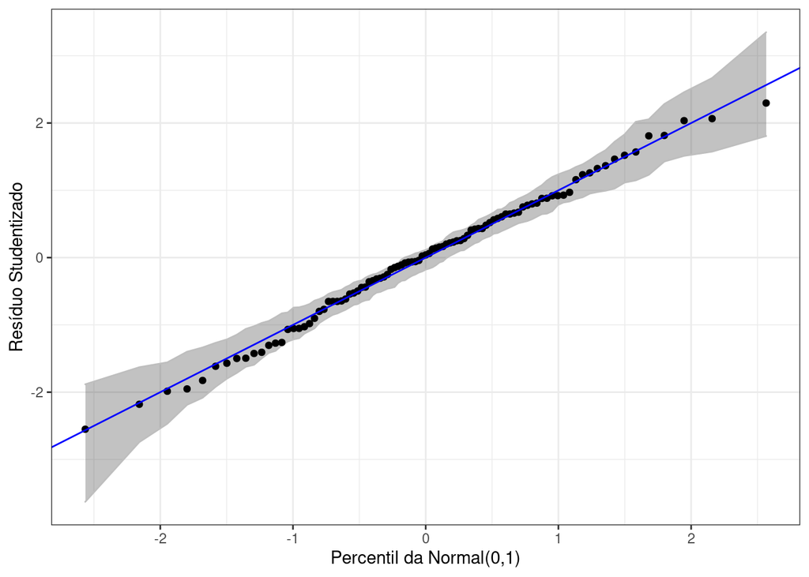

```r
qqnormb <- function(X, Y, Z){
li <- qqnorm(X, plot.it = F)
x  <- qqnorm(Y, plot.it = F)
ls <- qqnorm(Z, plot.it = F)

data <- data.frame(lix = li$x, liy = li$y, xx= x$x, xy = x$y ,lsx = ls$x, lsy = ls$y)

require(ggplot2)
 p <- ggplot(data, aes(lix,liy, xx,xy, lsx,lsy)) + geom_ribbon(aes(ymin = liy, ymax = lsy), alpha = 0.3, col = "grey") + geom_point(aes(xx, xy))
 return(p)
}
#---------------------------------------------------------------#
par(mfrow=c(1,1))
X <- model.matrix(MF)
n <- nrow(X)
p <- ncol(X)
H <- X%*%solve(t(X)%*%X)%*%t(X)
h <- diag(H)
si <- lm.influence(MF)$sigma
r <- resid(MF)
tsi <- r/(si*sqrt(1-h))
#
ident <- diag(n)
epsilon <- matrix(0,n,100)
e <- matrix(0,n,100)
e1 <- numeric(n)
e2 <- numeric(n)
#
for(i in 1:100){
 epsilon[,i] <- rnorm(n,0,1)
 e[,i] <- (ident - H)%*%epsilon[,i]
 u <- diag(ident - H)
 e[,i] <- e[,i]/sqrt(u)
 e[,i] <- sort(e[,i]) }
#
for(i in 1:n){
 eo <- sort(e[i,])
 e1[i] <- (eo[2]+eo[3])/2
 e2[i] <- (eo[97]+eo[98])/2 }
#
med <- apply(e,1,mean)
faixa <- range(tsi,e1,e2)
#
#--------------------------------------------------------------#

qqnormb(e1, tsi, e2) + theme_bw() + xlab("Percentil da Normal(0,1)") + ylab("Resíduo Studentizado") + geom_abline(slope = 1, intercept = 0, col = "blue")
```

$\textbf{Análise:}$ O gráfico qqplot dos resíduos com banda de confiança serve para checar a normalidade dos erros. Se todos os pontos estiverem dentro da banda, podemos assumir que os erros têm distribuição normal. Sendo assim verificamos que todos os pontos estão sobre a reta e dentro das bandas com 95% de confiança. A seguir temos o histograma da distribuição dos resíduos Studentizados para confirmar essa hipótese.

### - Histograma dos Resíduos Studentizados

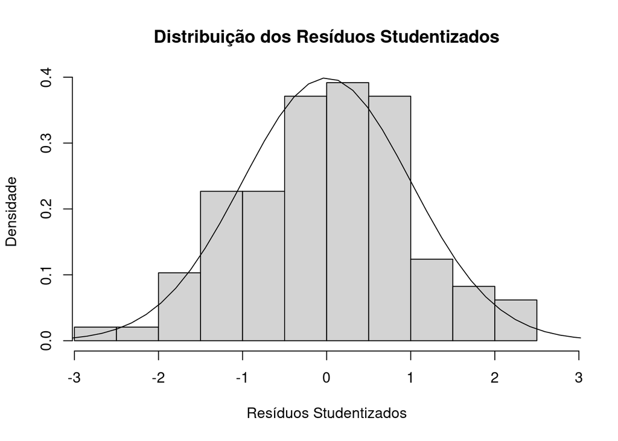

```r
library(MASS)
sresid <- studres(MF)
hist(sresid, freq=FALSE, main="Distribuição dos Resíduos Studentizados", xlab = "Resíduos Studentizados", ylab = "Densidade", xlim = c(-2.8, 2.8))
xm <- seq(-1+min(sresid), 1+max(sresid), length=40)
ym <- dnorm(xm)
lines(xm, ym)
```

### – Medidas de Alavanca, Pontos Influentes, Discrepantes e Outliers

#### – Comandos auxiliares para os demais gráficos

```r
X <- model.matrix(MF)  # Matriz do modelo ajustado
lms <- summary(MF)
n <- nrow(X)
p <- ncol(X)
H <- X%*%solve(t(X)%*%X)%*%t(X) # Matriz Hat
h <- diag(H)  # Diagonal da matriz Hat (hii, medida de alavanca)
s <- lms$sigma
r <- resid(lms) # Residuos
ts <- r/(s*sqrt(1-h))
di <- (1/p)*(h/(1-h))*(ts^2) # Distância de cook
si <- lm.influence(MF)$sigma
tsi <- r/(si*sqrt(1-h)) # Resíduo Studentizado
```

#### – Agora vamos ao primeiro gráfico, o da medida de alavanca

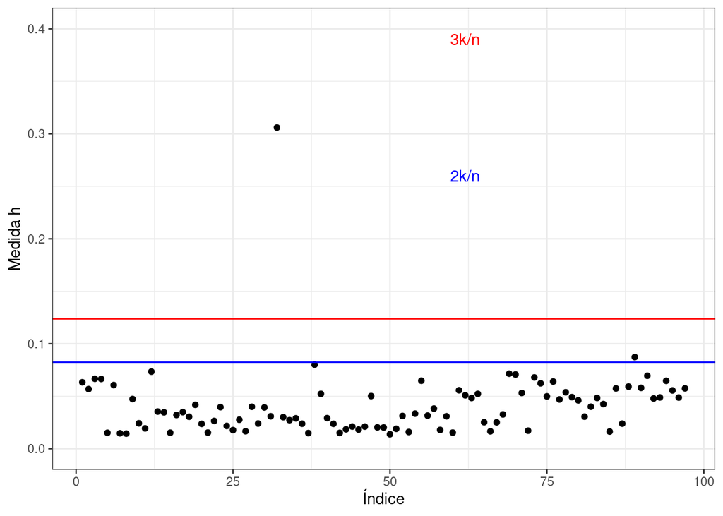

```r
h <- data.frame(h = h, i = c(1:(length(h))))
ggplot(h, aes(i, h)) + geom_point() + ylim(0, 0.4) + xlab("Índice") + ylab("Medida h") + theme_bw() + geom_abline(slope = 0, intercept = 2*p/n, col = "blue", type = "dashed") + geom_abline(slope = 0, intercept = 3*p/n, col = "red", type = "dashed") + annotate("text", x=62, y=0.26, label= "2k/n", col = "blue") + annotate("text", x=62, y=0.39, label= "3k/n", col = "red")
```

#### – Agora vamos fazer o gráfico da Distância de Cook,

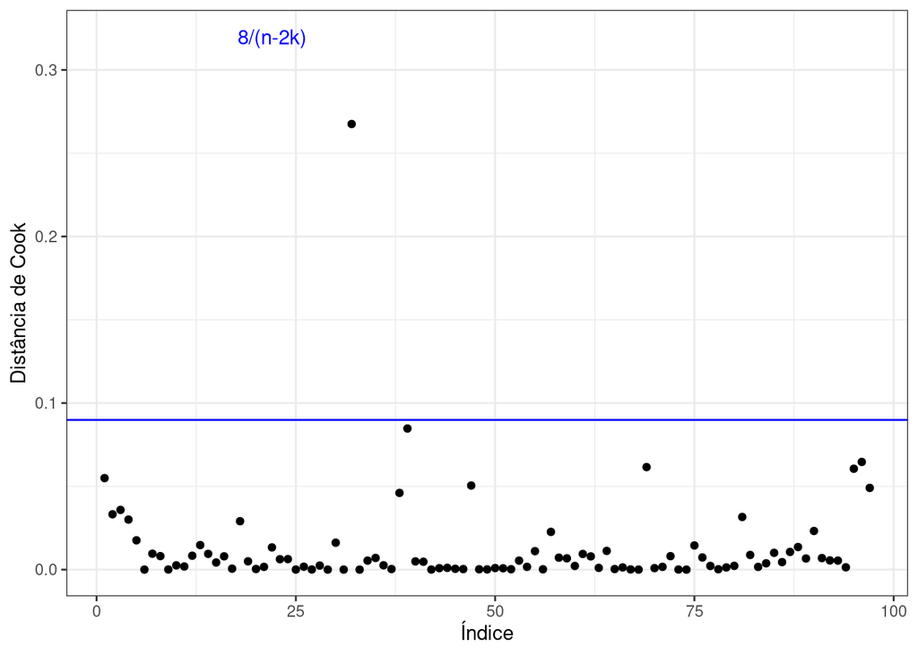

```r
di <- data.frame(di = di, i = c(1:97))
plot <- ggplot(di, aes(i, di)) + geom_point() + xlab("Índice") + ylab("Distância de Cook") + theme_bw() + geom_abline(slope = 0, intercept = 8/(nobs - 2*4), col = "blue")
plot + annotate("text", x=22, y=0.32, label= "8/(n-2k)", col = "blue")
```

#### – Agora vamos fazer o gráfico de resíduos studentizados pelo índice

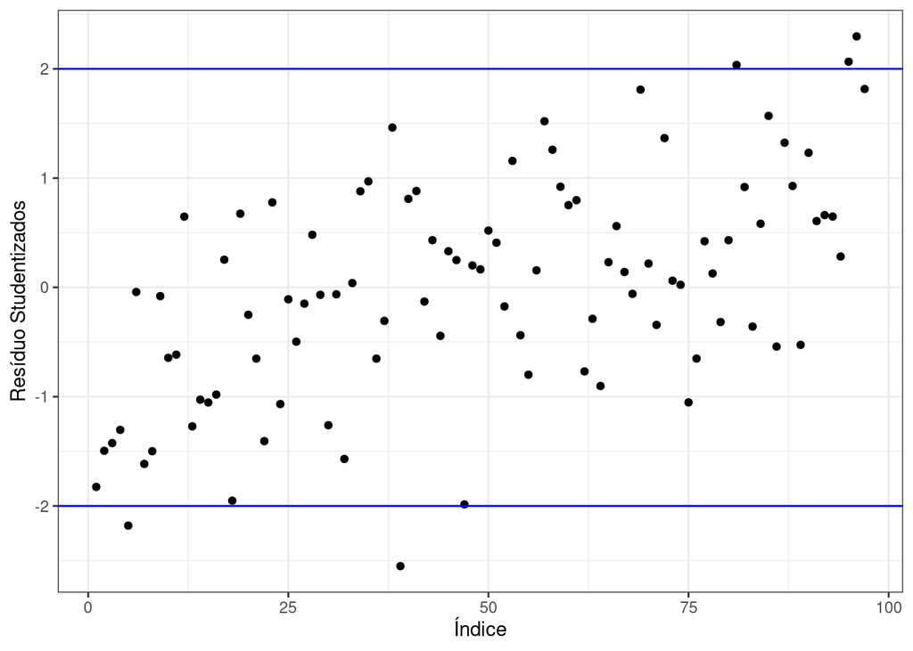

```r
tsi <- data.frame(tsi = tsi, i = 1:nobs)
ggplot(tsi, aes(i, tsi)) + geom_point() + theme_bw() + xlab("Índice") + ylab("Resíduo Studentizados") + geom_hline(yintercept = -2, col = "blue") + geom_hline(yintercept = 2, col = "blue")
```

$\textbf{Análise:}$ O gráfico de resíduos studentizados pelo índice serve para verificar se a suposição de independência dos erros é plausível. Além disso serve para identificar pontos discrepantes, com resíduo alto. Neste caso percebemos que os pontos estão entre $-2$ e 2 com exceção de cinco pontos fora do intervalo $[-2,2]$. Pórem, mesmo assim, se mostra no padrão.

#### – O próximo gráfico é de resíduo studentizado versus valor ajustado

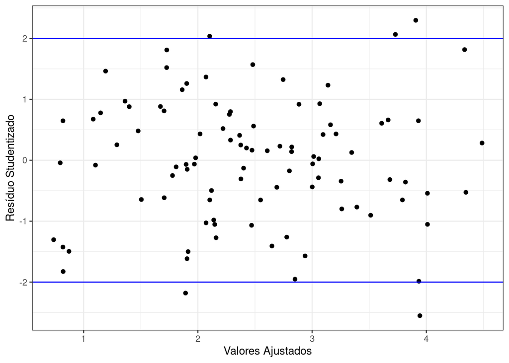

```r
df <- data.frame(tsi = tsi$tsi, fit = MF$fitted)
ggplot(df, aes(fit, tsi)) + geom_point() + geom_hline(yintercept = -2, col = "blue") + geom_hline(yintercept = 2, col = "blue") + xlab("Valores Ajustados") + ylab("Resíduo Studentizado") + theme_bw()
```

$\textbf{Análise:}$ O gráfico de resíduos studentizados pelos valores ajustados serve para verificar se a suposição de independência dos erros é plausível. Além disso serve para identificar pontos discrepantes, com resíduo alto. Neste caso percebemos que os pontos estão entre $-2$ e 2 com exceção de 5 pontos fora do intervalo $[-2,2]$. Mas, mesmo assim, se mostra no padrão.

### – DFFITS

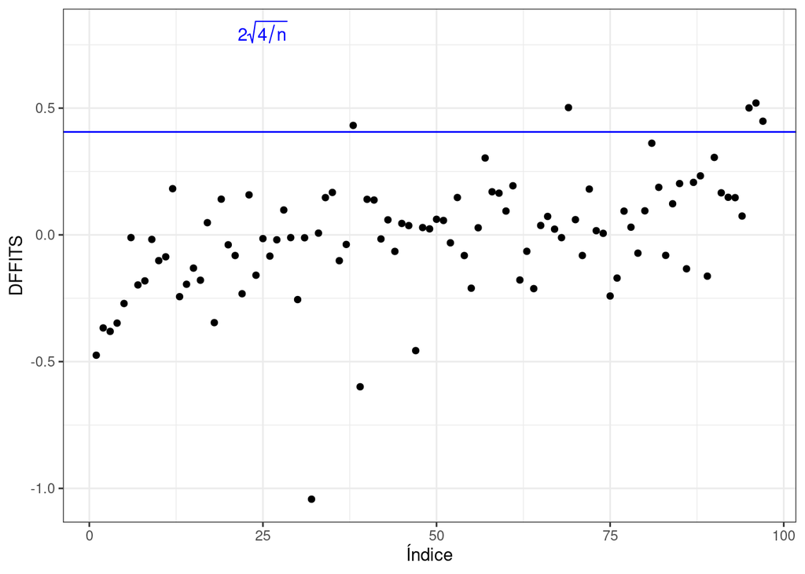

```r
library(stats)
dff <- data.frame(dff = dffits(MF), i = 1:nobs)
plot <- ggplot(dff, aes(i, dff)) + geom_point() + theme_bw() + xlab("Índice") + ylab("DFFITS") + geom_hline(yintercept = 2*sqrt(4/nobs), col = "blue")
plot + annotate("text", x=25, y=0.80, label= expression(2*sqrt(4/n)), col = "blue")
```

$\textbf{Análise:}$ O gráfico DFFITS serve para mostrar como é influente o ponto em uma regressão linear múltipla. Neste caso percebemos que os pontos estão abaixo da reta com exceção de 5 pontos que estão acima da reta. Mas, mesmo assim, consideramos no padrão.